# Initial analysis

César Soto Valero

17 June, 2020

# 1 Prepare dataset

The raw dataset has **81 libs**, **613 libs GAV**, and **7986 clients**, with information of the following variables:

```
##  [1] "ID"                           "Lib_groupId"
##  [3] "Lib_artifactId"               "Lib_version"
##  [5] "Compile"                      "Debloat"
##  [7] "Lib_original_test_error"      "Lib_original_test_failing"
##  [9] "Lib_original_test_passing"    "Lib_debloat_test_error"
## [11] "Lib_debloat_test_failing"     "Lib_debloat_test_passing"
## [13] "Size_original_jar"            "Size_debloat_jar"
## [15] "Nb_classes_original"          "Nb_methods_original"
## [17] "Nb_debloated_classes"         "Nb_debloated_methods"
## [19] "Lib_coverage"                 "Client_groupId"
## [21] "Client_artifactId"            "Client_Compile"
## [23] "Client_Debloat"               "Client_original_test_error"
## [25] "Client_original_test_failing" "Client_original_test_passing"
## [27] "Client_debloat_test_error"    "Client_debloat_test_failing"
## [29] "Client_debloat_test_passing"  "Client_coverage"
## [31] "Cover_lib"                    "Lib"
## [33] "Lib_gav"                      "Client"
```

# 2 Overall lib debloat success

A total of 468 **different libs GAVs** were debloated successfully, whereas 144 fail.

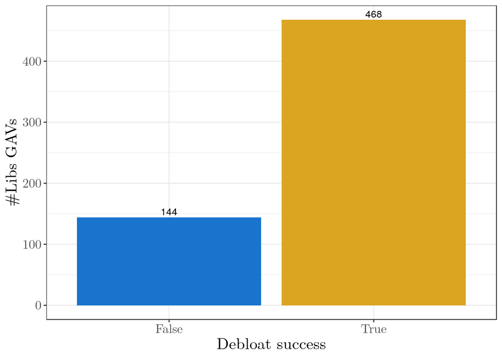

For the rest of the analysis, we exclude the libs for which the debloat fail, this results in a dataset with 72 **different libs**, 468 **different libs GAV**, and 4351 **different clients**.

# 3 Distribution of versions per library

The lib `com.alibaba:fastjson` has the larger number of **different versions** with 35, followed by `joda-time:joda-time` with 25, and `redis.clients:jedis` with 23.

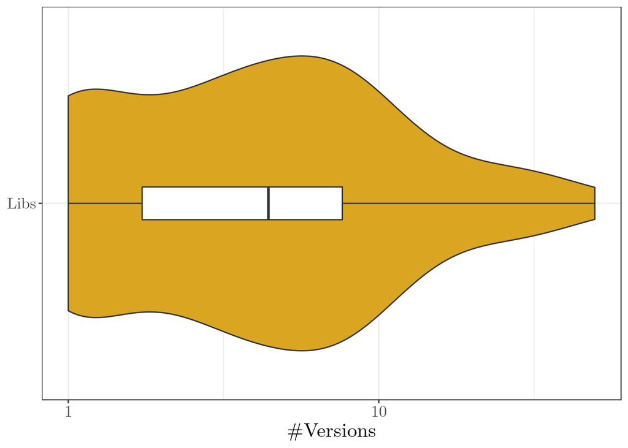

| Lib_artifactId | Nb_Versions |
| --- | --- |
| fastjson | 35 |
| joda-time | 25 |
| jedis | 23 |
| jsoup | 23 |
| sqlite-jdbc | 22 |
| jackson-module-jaxb-annotations | 17 |
| gson | 15 |
| jettison | 13 |
| commons-io | 12 |
| equalsverifier | 12 |

[output cut: 62 more lines]

# 4 Distribution of clients per library

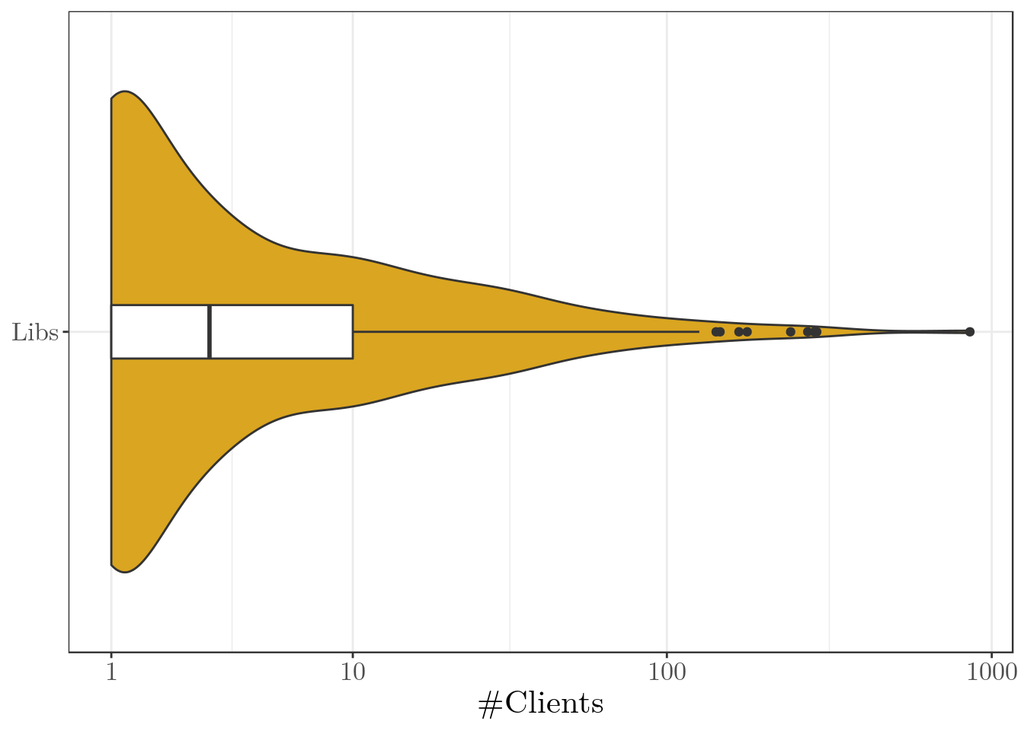

| Lib_gav | Nb_Clients |
| --- | --- |
| commons-io:commons-io:2.4 | 857 |
| commons-io:commons-io:2.6 | 290 |
| commons-io:commons-io:2.5 | 285 |
| commons-cli:commons-cli:1.2 | 272 |
| commons-codec:commons-codec:1.10 | 241 |
| com.google.code.gson:gson:2.2.4 | 177 |
| commons-codec:commons-codec:1.9 | 167 |
| com.google.code.gson:gson:2.3.1 | 146 |
| redis.clients:jedis:2.9.0 | 142 |
| com.googlecode.json-simple:json-simple:1.1.1 | 126 |

[output cut: 458 more lines]

# 5 Libs test results (global)

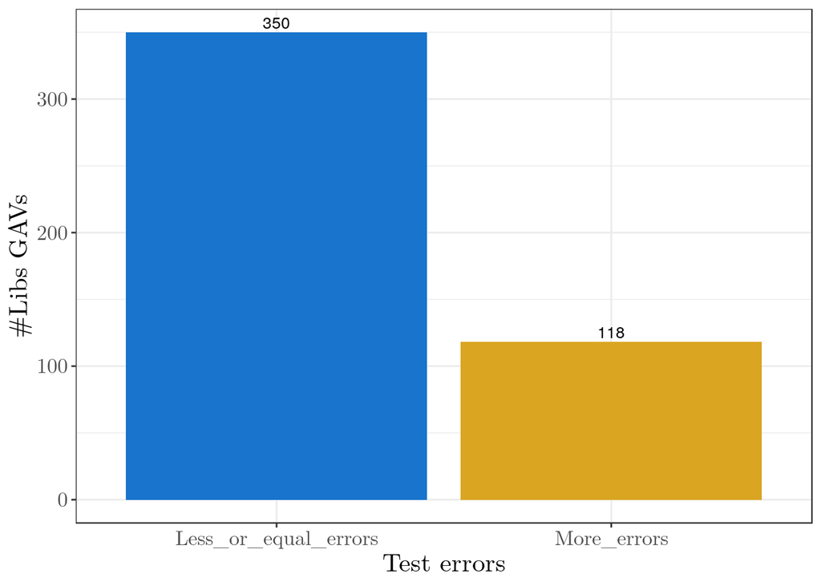

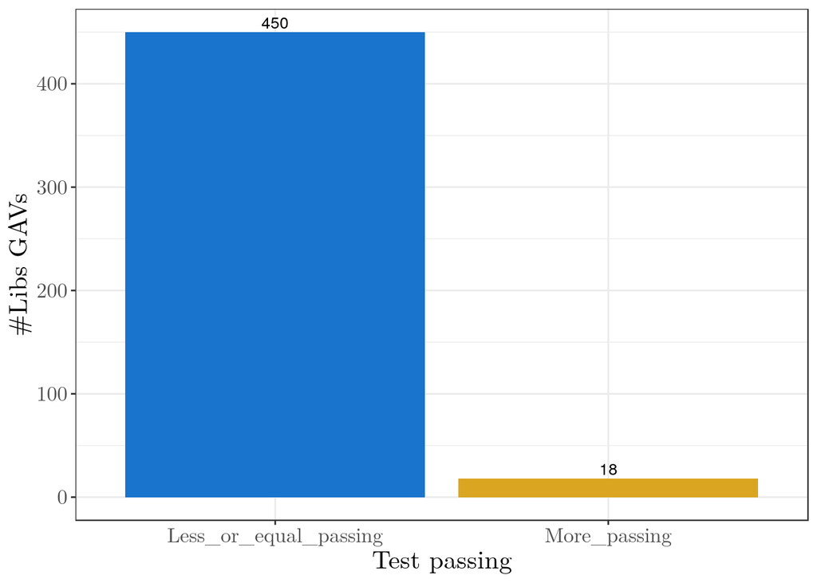

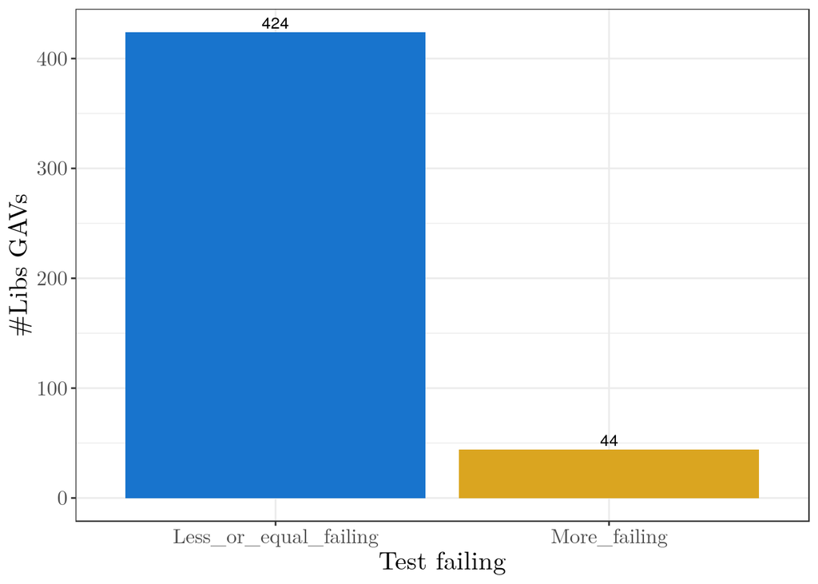

# 6 Libs test results (per lib)

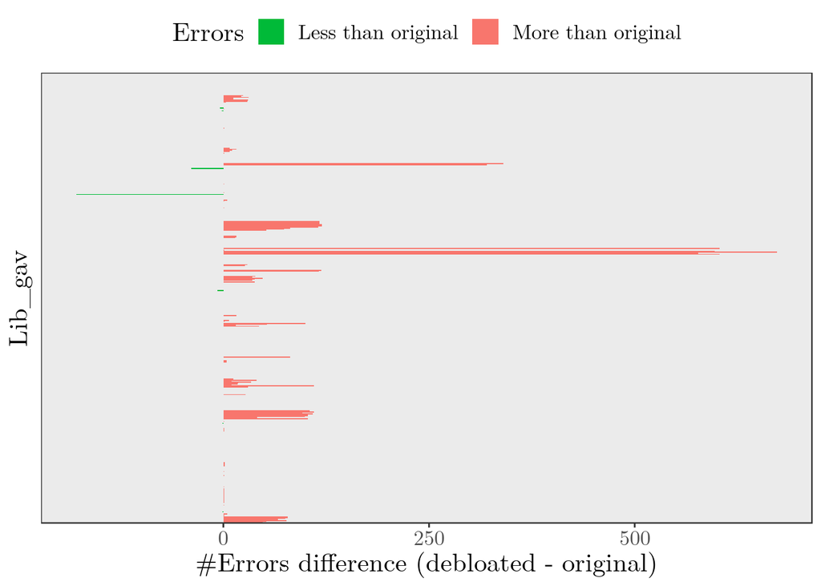

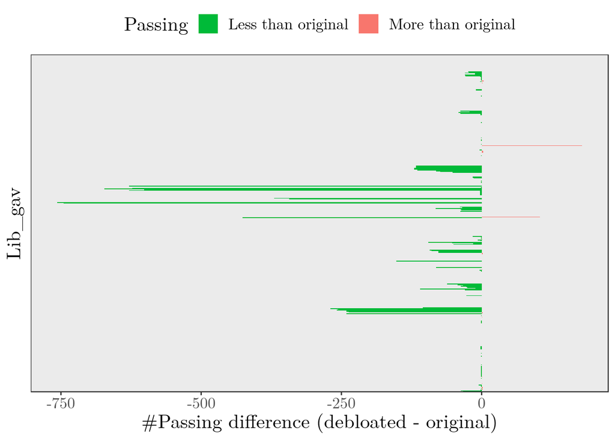

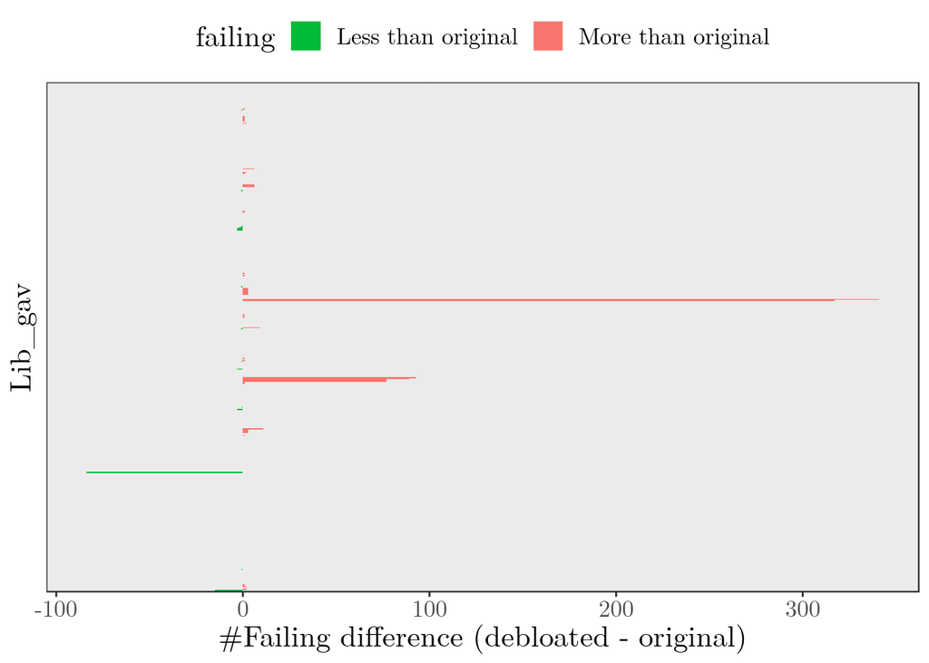

# 7 Libraries and dependencies

## 7.1 Libraries

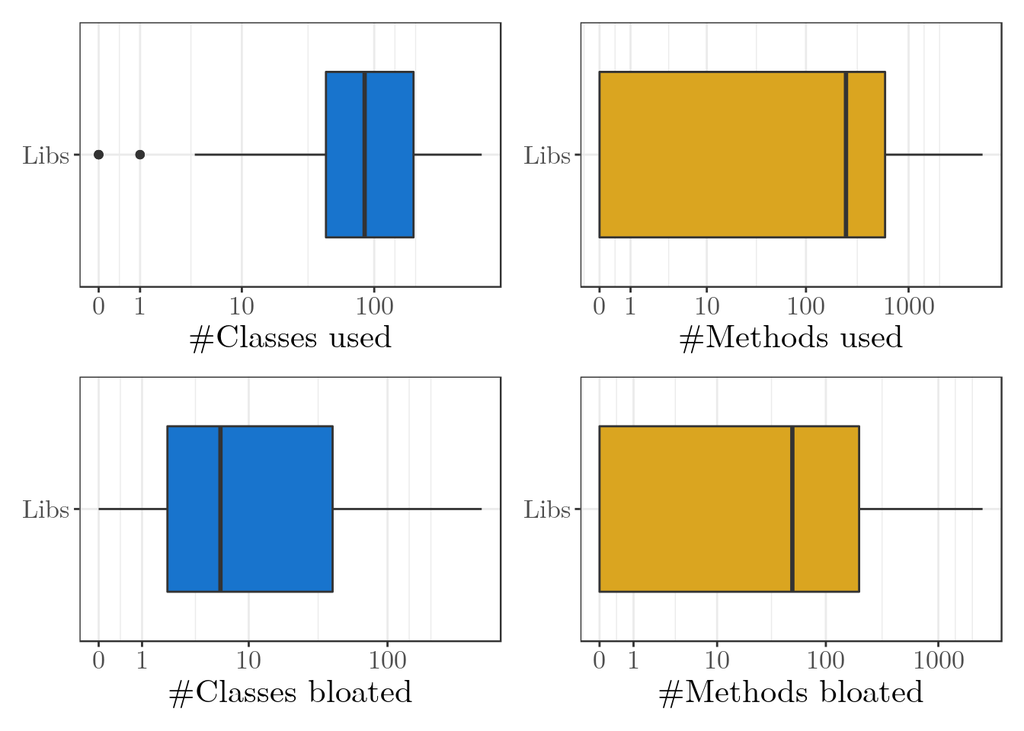

## 7.2 Dependencies

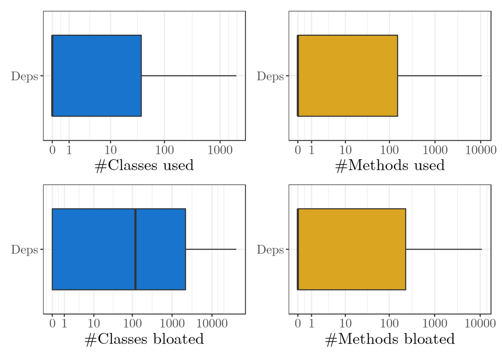

# 8 Libs Classes

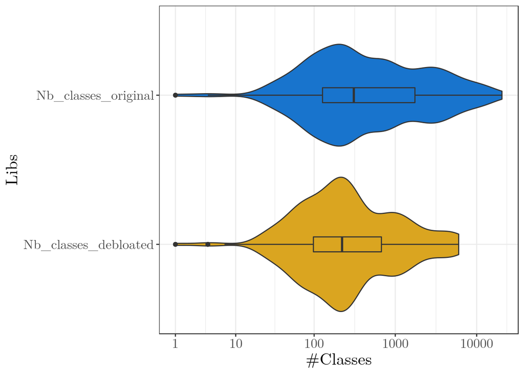

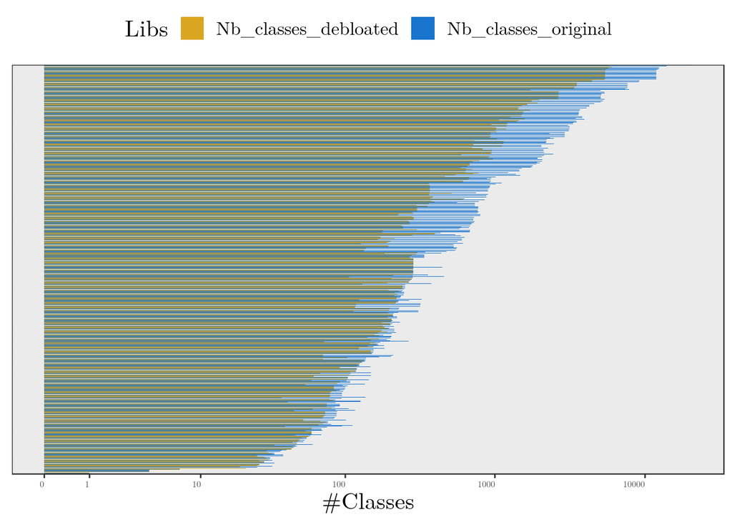

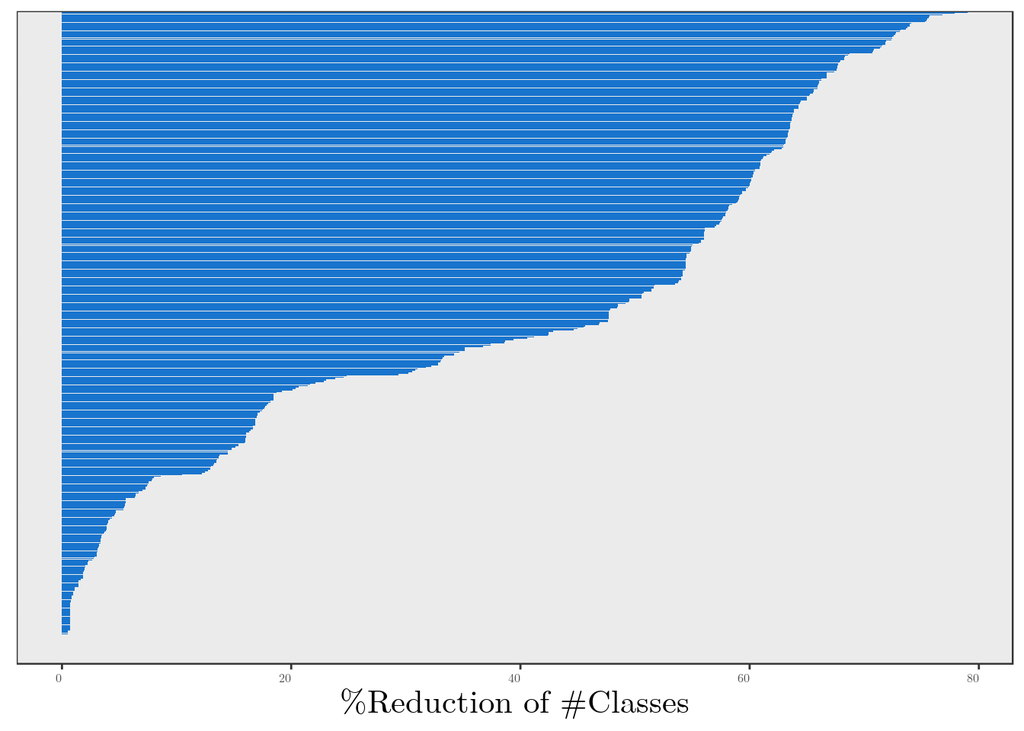

# 9 Libs methods

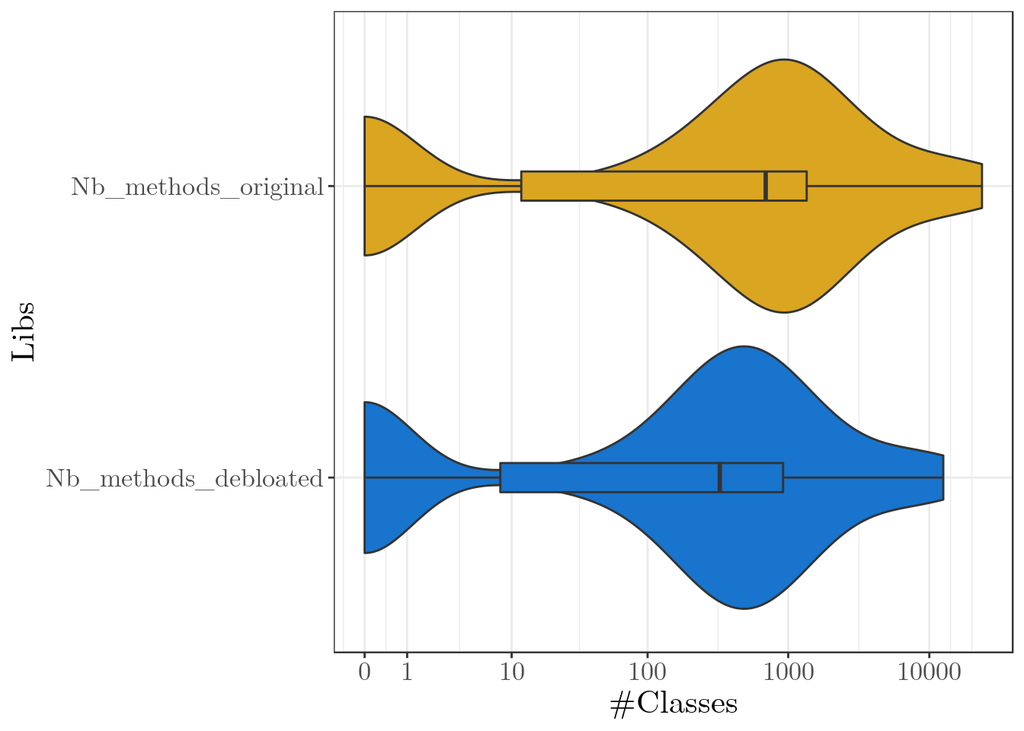

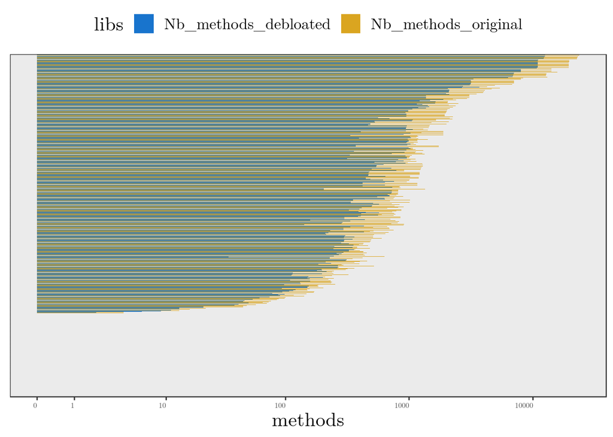

Percentage of methods reduced per library.

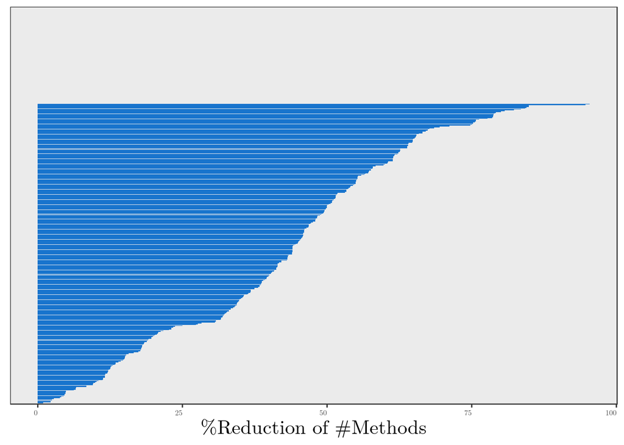

There are some libs, such as DiUS_java-faker, for which the #Methods is equal zero. These are those libraries:

| Lib_gav |
| --- |
| com.github.javafaker:javafaker:0.16 |
| com.github.javafaker:javafaker:1.0.1 |
| com.fasterxml.jackson.dataformat:jackson-dataformat-csv:2.3.3 |
| com.fasterxml.jackson.datatype:jackson-datatype-jsr310:2.6.4 |
| com.fasterxml.jackson.datatype:jackson-datatype-jsr310:2.4.2 |
| com.fasterxml.jackson.datatype:jackson-datatype-jsr310:2.4.5 |
| com.fasterxml.jackson.datatype:jackson-datatype-jsr310:2.7.6 |
| com.fasterxml.jackson.datatype:jackson-datatype-jsr310:2.4.4 |
| com.fasterxml.jackson.datatype:jackson-datatype-jsr310:2.7.1 |
| com.fasterxml.jackson.datatype:jackson-datatype-jsr310:2.7.4 |

[output cut: 104 more lines]

# 10 Lib coverage

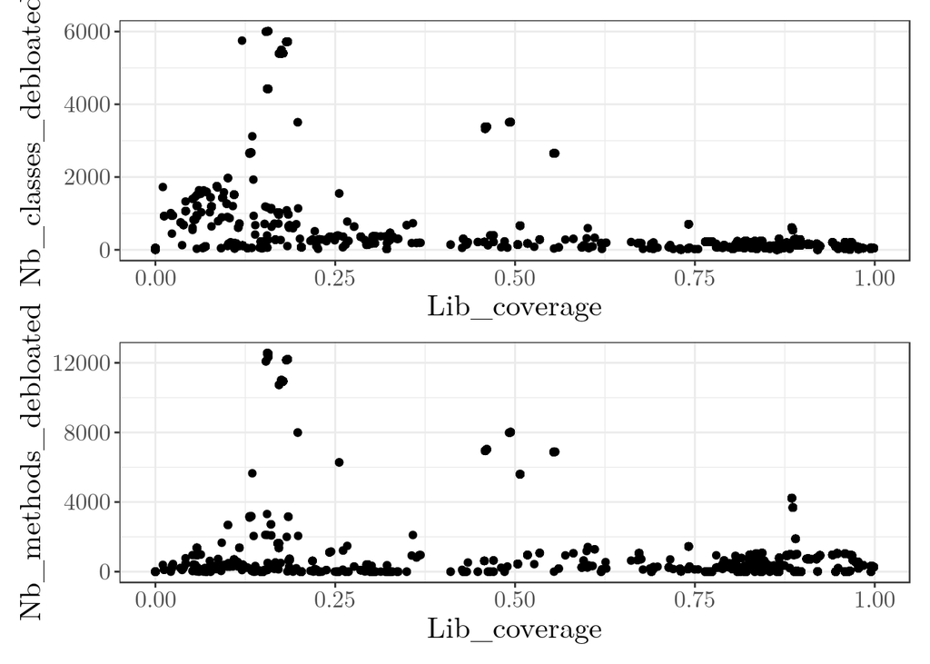

# 11 Size of the JAR

The size of the debloated jar is slightly bigger than the original one. It seems that JDBL is adding some dependencies or resourses that should’t be included in the bundled jar. We need to invesitigate this in more details.

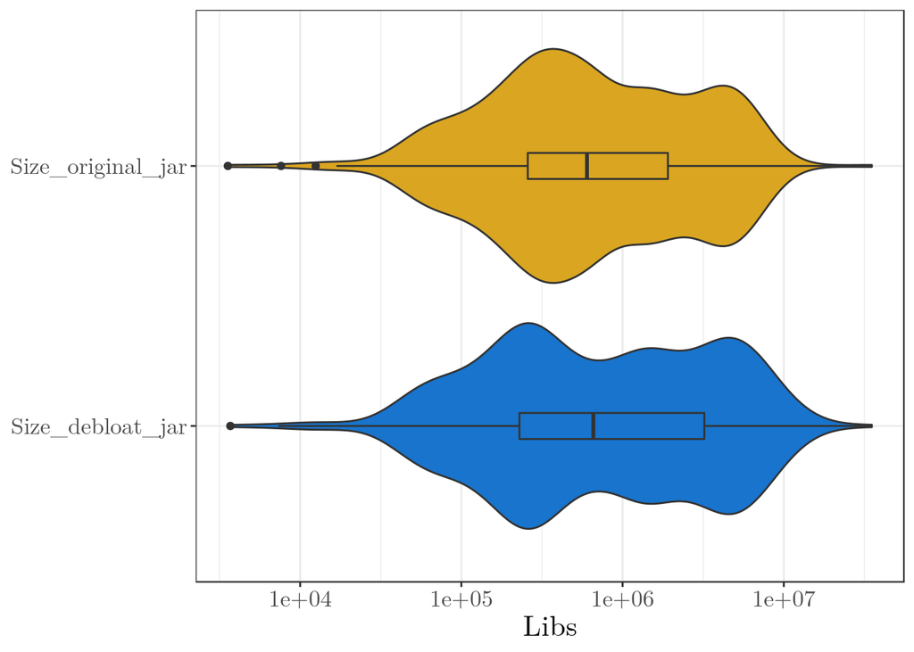

Let’s see wich are those libraries for which the debloated jar is bigger than the original one.

| Lib_gav | Size_original_jar | Size_debloat_jar | Diff_size |
| --- | --- | --- | --- |
| com.alibaba:fastjson:1.2.59 | 641473 | 13606284 | 12964811 |
| com.alibaba:fastjson:1.2.62 | 659258 | 13622777 | 12963519 |
| com.alibaba:fastjson:1.2.58 | 640523 | 13534982 | 12894459 |
| com.alibaba:fastjson:1.2.56 | 3158583 | 10658638 | 7500055 |
| com.alibaba:fastjson:1.2.54 | 590973 | 8083139 | 7492166 |
| com.alibaba:fastjson:1.2.51 | 580824 | 8072024 | 7491200 |
| com.alibaba:fastjson:1.2.57 | 3196095 | 10642289 | 7446194 |
| com.alibaba:fastjson:1.2.47 | 547556 | 7689363 | 7141807 |
| com.alibaba:fastjson:1.2.37 | 515286 | 7603974 | 7088688 |
| com.alibaba:fastjson:1.1.37 | 515286 | 7603926 | 7088640 |

[output cut: 135 more lines]

Let’s see plot the difference in size between the debloatead and the original JARs.

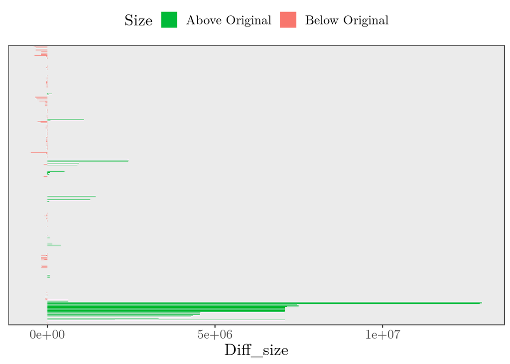

# 12 Client plots

## 12.1 Client Test results original vs test debloated

```
## [1] "#Clients original with at least one test error: "
```

```
## [1] 7050
```

```
## [1] "#Clients debloated with at least one test error: "
```

```
## [1] 828
```

```
## [1] "#Clients original with zero test error: "
```

```
## [1] 0
```

```
## [1] "#Clients debloated with zero test error: "
```

```
## [1] 6222
```

```
## [1] "#Clients debloated with zero test error and at least one debloated test error: "
```

```
## [1] 0
```

```
## [1] "#Clients debloated wigh zero test error and at least one debloated test error: "
```

```
## [1] 7050
```

[output not shown]

```
## [1] 318
```

```
## [1] "#Clients debloated with at least one test fail: "
```

```
## [1] 318
```

```
## [1] "#Clients original with zero test fail: "
```

```
## [1] 6732
```

```
## [1] "#Clients debloated with zero test fail: "
```

```
## [1] 6732
```

```
## [1] "#Clients debloated with zero test fail and at least one debloated test fail: "
```

```
## [1] 0
```

```
## [1] "#Clients debloated wigh zero test fail and at least one debloated test fail: "
```

```
## [1] 0
```

```
## [1] "#Clients original with at least one test pass: "
```

```
## [1] 2530
```

```
## [1] "#Clients debloated with at least one test pass: "
```

```
## [1] 2126
```

```
## [1] "#Clients original with zero test pass: "
```

```
## [1] 4520
```

```
## [1] "#Clients debloated with zero test pass: "
```

```
## [1] 4924
```

```
## [1] "#Clients debloated with zero test pass and at least one debloated test pass: "
```

```
## [1] 0
```

```
## [1] "#Clients debloated wigh zero test pass and at least one debloated test pass: "
```

```
## [1] 0
```

## 12.2 Violin plots

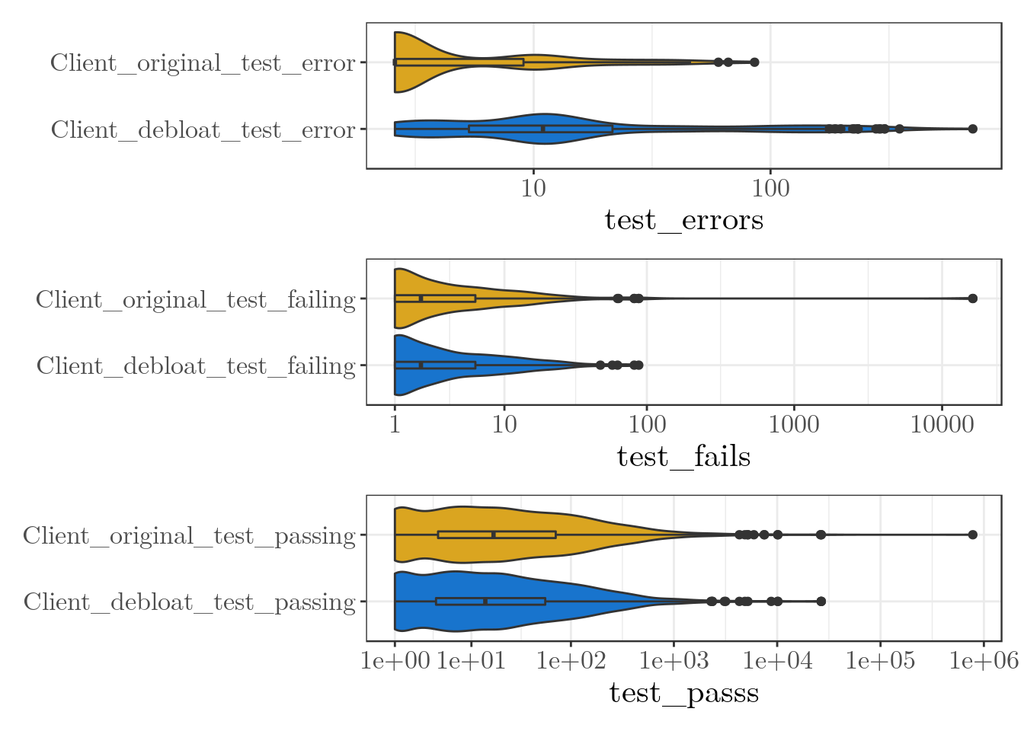

## 12.3 Bar plots

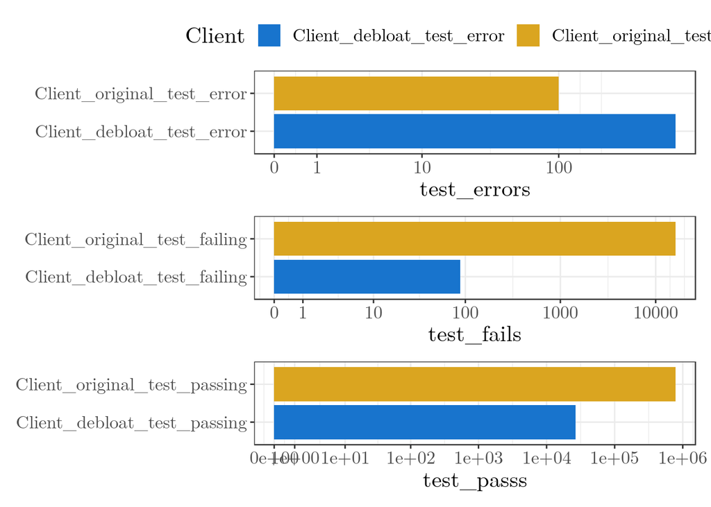